# Potential Animal Study Data Source Summaries

### mRNA vaccines encoding computationally optimized hemagglutinin elicit protective antibodies against future antigenically drifted H1N1 and H3N2 influenza viruses isolated between 2018-2020 (Allen and Ross 2024)

- **First/Last Authors:** James D. Allen/Ted M. Ross
- **Author we know (loc):** Ted M. Ross
- **Animal Model:** Mouse/Murine
- **Summary:** “Overall, this was the first time that mRNA encoding COBRA HA antigens were synthesized and used to vaccinate immunologically naïve mice to determine their effectiveness at eliciting broadly protective antibody responses against diverse panels of H1N1 and H3N2 vaccine strains from the last decade. These responses were superior to those elicited by wild-type mRNA expressing HA antigens at inhibiting viral binding to host cell surface receptors and preventing viral infection. Thus, demonstrating the potential benefits of using in-silico designed influenza mRNA vaccine antigens to elicit more broadly protective immune responses over traditional wild-type vaccine antigens.”
- **Notes:**
  - “At the beginning of the study the mice were randomly divided into 10 groups (n=11 mice/group), and vaccinated intramuscularly with 50mL of a solution containing 1mg of mRNA vaccines encoding the HA proteins of either the H1 COBRA Y2, H1 A/California/07/2009, H3 COBRA NG2 or H3 A/Kansas/14/2017 in phosphate buffered saline (PBS), or 50mL of PBS alone as a placebo control vaccine (24, 30, 50). The **vaccines were administered as either a monovalent (1mg) or bivalent (H1 + H3) (1mg each) formulation intramuscularly** into the hamstring of the hind leg of the mice on the first day of the study and again on day 28. **Blood samples were obtained from the facial vein of the animals on day 14 and day 42 post initial vaccination**.”
  - “On **day 56 post initial vaccination, 55 of the mice (n= [11] mice/group) were infected with 50 mL of a human A/California/07/2009 H1N1 influenza isolate** that has been passaged in eggs (EP4) at a dose of 5x104 PFU/50mL. Also on day 56 post initial vaccination, another set of 55 mice (n=11 mice/group) were challenged with 50mL of a human A/Kansas/14/2017 H3N2 influenza isolate that has been passaged in eggs (EP1) at a dose of 1.55x107 PFU/50mL. **Mice were observed for 14 consecutive days after infection for weight loss and clinical signs of infection**. A humane 25% weight loss cut off was observed for all mice, post infection, as previously established by the IACUC committee. On the third day of the viral challenge, 3 mice from each group were humanely euthanized, and their lungs were removed, snap frozen, and stored at -80°C. Following day 14 of the influenza virus challenge, all mice were humanely euthanized using IACUC approved methods.”
  - We already have this data from Yao

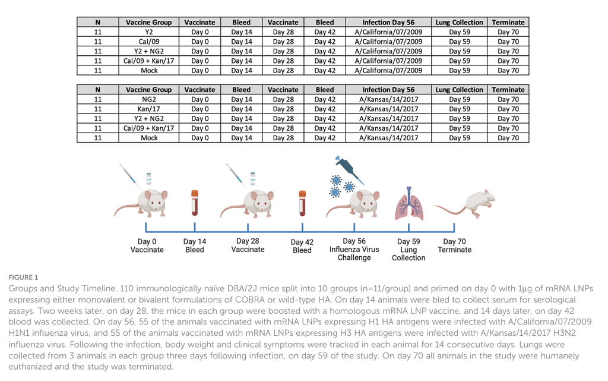

### A recombinant N2 neuraminidase-based CpG 1018® adjuvanted vaccine provides protection against challenge with heterologous influenza viruses in mice and hamsters (Hoxie et al. 2024)

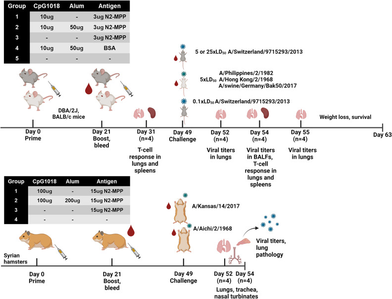

### Intranasal administration of octavalent next-generation influenza vaccine elicits protective immune responses against seasonal and pre-pandemic viruses (Uno et al. 2024)

- **First/Last Authors:** Naoko Uno/Ted M. Ross
- **Author we know:** Ted M. Ross (last)
- **Animal Model:** Ferret
- **Summary:** “Octavalent mixtures of COBRA hemagglutinin (HA) (H1, H2, H3, H5, H7, and influenza B virus) plus neuraminidase (NA) (N1 and N2) recombinant proteins mixed with c-di-AMP adjuvant were administered intranasally to naive or pre-immune ferrets in prime-boost fashion. Four weeks after final vaccination, collected sera were analyzed for breadth of antibody response, and the animals were challenged with seasonal or pre-pandemic strains. The octavalent COBRA vaccine elicited antibodies that recognized a broad panel of strains representing different subtypes, and these vaccinated animals were protected against influenza virus challenges. Overall, this study demonstrated that the mixture of eight COBRA HA/NA proteins mixed with an intranasal adjuvant is a promising candidate for a universal influenza vaccine.”
- **Notes:**
  - “Ferrets were randomly divided into [four] vaccine groups, and each vaccine group had **three different infection groups (n = 4–6)**. The groups were pre-immune ferrets given octavalent COBRA vaccine, naive ferrets given octavalent COBRA vaccine, pre-immune ferrets given mock vaccine, and naive ferrets given mock vaccine.”
  - “For the pre-immune groups, ferrets that had been previously exposed to CA/09 prior to this study were infected with Pan/99 and B/HK/01 60 days prior to vaccination.”
  - “Ferrets were **boosted 28 days after initial vaccination**. Blood was harvested from all anesthetized ferrets via the anterior vena cava prior to vaccination and at days 28 and 56 post-initial vaccination.”
  - “On day 56 post-vaccination, ferrets were challenged i.n. with H1N1 Bris/18 (108 PFU), IBV B/WA/19 (107 PFU), or a lethal dose of H5N1 Vn/04 (105 PFU, BSL3 select agent) viruses in a volume of 1 mL (n = 5 per vaccine group per challenge).”
  - “Ferrets were **monitored daily** for weight loss, disease signs, and death for 10 days after infection. Experimental endpoints were defined as >20% wt loss compared to initial body weight. Additionally, dyspnea, lethargy, response to external stimuli, and other respiratory distress were closely monitored for the determination of humane endpoint.”

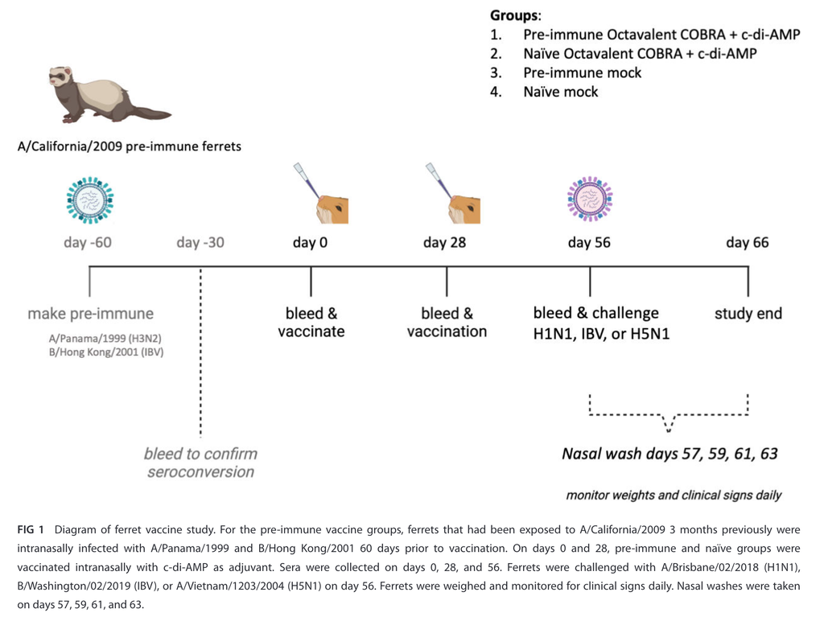

### Matrix Protein 2 Extracellular Domain-Specific Monoclonal Antibodies Are an Effective and Potentially Universal Treatment for Influenza A (Bimler et al. 2021)

- **First/Last Authors:** Lynn Bimler/Silke Paust
- **Author we know (loc):** Mark Tompkins (second to last)
- **Animal Model:** Mouse/Murine
- **Summary:** “We generated seven murine M2e-MAbs and utilized in vitro and in vivo assays to validate the specificity of our novel M2eMAbs and to explore the universality of their protective potential. Our data show our M2e-MAbs bind to the M2e peptide, HEK cells expressing the M2 channel, as well as influenza virions, and MDCK-ATL cells infected with influenza viruses of multiple serotypes. Our antibodies significantly protect BALB/c mice that are highly susceptible to influenza A virus from lethal challenge with H1N1 A/PR/8/34, pH1N1 A/CA/07/2009, H5N1 A/Vietnam/1203/2004, and H7N9 A/Anhui/1/2013 by improving survival rates and weight loss. Based on these results, at least four of our seven M2e-MAbs show strong potential as universal influenza A treatments.”
- **Notes:**
  - Conducted at Baylor College of Medicine *and* UGA
  - “We **vaccinated 3 times 21 days apart** prior to boosting, as this protocol has been demonstrated to produce consistently high antibody titers in all IgG subclasses (significantly higher than 2 vaccinations) and to produce memory B cells that can be activated to produce an increased antibody titer even to geriatric age in mice, 16 months postvaccination.”
  - “Mice were given an intraperitoneal (i.p.) injection of the specified **MAb at a specified dose 24 hours before virus challenge with 10x the 50% lethal dose (LD50)** of the specified virus. H1N1 challenge virus was administered in 20ml of PBS intranasally to mice anesthetized with isoflurane. The pH1N1 and H5N1 challenge viruses were administered in 30ml of PBS intranasally to mice anesthetized with ketamine/xylazine. The H7N9 virus was administered intranasally to mice anesthetized with 2,2,2-tribromoethanol in tert-amyl alcohol (avertin; Aldrich Chemical Co.). The viral inoculum titer of each challenge with pH1N1, H7N9, and H5N1 was determined on MDCK-ATL cells to confirm dose. If specified, a subset of mice were humanely euthanized, and tissues collected to determine virus titer 3 days postinfection (dpi). All animals were monitored for body weight and humane endpoints for euthanization. **Survival and weight loss were monitored for up to 21 dpi or until all animals recovered to at least 90% starting body weight.**”

### Nebulized Live-Attenuated Influenza Vaccine Provides Protection in Ferrets at a Reduced Dose (Smith et al. 2012)

- **First/Last Authors:** Jennifer Humberd Smith/Ralph A. Tripp
- **Author we know (loc):** Mark Tompkins (2nd to last)
- **Animal Model:** Ferret
- **Summary:** “We investigated LAIV vaccination in ferrets using a high efficiency nebulizer designed for nasal delivery. LAIV nasal aerosol elicited high levels of serum neutralizing antibodies and protected ferrets from homologous virus challenge at conventional (107 TCID50) and significantly reduced (103 TCID50) doses. Aerosol LAIV also provided a significant level of subtype-specific cross protection. These results demonstrate the dose-sparing potential of nebulizer-based nasal aerosol LAIV delivery.”
- **Notes:**
  - “Ferrets were anesthetized . . . and **inoculated** intranasally with 0.2 ml (0.1 ml/nostril) or by aerosol (0.2 ml estimated dose) using a AeroVax™ nebulizer, with either $10^3$ or $10^7$ TCID50 of **SD-LAIV** for the homologous virus challenge study and $10^5$ TCID50 of SD-LAIV or CA09 for the heterotypic challenge study.
  - “Ferrets were **challenged 21 days post vaccination** . . . Daily weights and temperatures were recorded for seven days after vaccination and/or challenge.”
  - “Sera samples were collected from each ferret **prior to inoculation, 14 days post exposure, and 14 or 17 days post challenge**. All sera were . . . tested in a **hemagglutination inhibition (HAI) assay** . . .”

## Confirmed data sources

### Acquired data

#### Allen and Ross (2024) - Section 2.1.2

## Denied/Rejected data sources

#### Abstract rejection

##### Chopra et al. (2024)

- No actual animal models - just receptor specificity

##### Curran et al. (2024)

- No pre-infection immunization

##### Lieber et al. (2023)

- No pre-infection immunization

##### Luczo et al. (2023)

- No pre-infection immunization

##### Pliasas et al. (2023)

- General methods match, but this is all swine, and I’m not sure we plan to look at swine (but if we do, this could move to potential)

##### Nachbagauer et al. (2018)

- No pre-infection immunization, other than monoclonal antibodies 24h prior to challenge

##### Driskell et al. (2010)

- No pre-infection immunization

## References

Allen, James D., and Ted M. Ross. 2024. “mRNA Vaccines Encoding Computationally Optimized Hemagglutinin Elicit Protective Antibodies Against Future Antigenically Drifted H1N1 and H3N2 Influenza Viruses Isolated Between 2018-2020.” *Front Immunol* 15 (March): 1334670. https://doi.org/10.3389/fimmu.2024.1334670.

Bimler, Lynn, Sydney L. Ronzulli, Amber Y. Song, Scott K. Johnson, Cheryl A. Jones, Teha Kim, Duy T. Le, S. Mark Tompkins, and Silke Paust. 2021. “Matrix Protein 2 Extracellular Domain-Specific Monoclonal Antibodies Are an Effective and Potentially Universal Treatment for Influenza A.” *J Virol* 95 (5): e01027–20. https://doi.org/10.1128/JVI.01027-20.

Chopra, Pradeep, Caroline K. Page, Justin D. Shepard, Sean D. Ray, Ahmed Kandeil, Trushar Jeevan, Andrew S. Bowman, et al. 2024. “Receptor Binding Specificity of a Bovine A(H5N1) Influenza Virus.” *bioRxiv*, July, 2024.07.30.605893. https://doi.org/10.1101/2024.07.30.605893.

Curran, Shelly J., Emily F. Griffin, Lucas M. Ferreri, Constantinos S. Kyriakis, Elizabeth W. Howerth, Daniel R. Perez, and S. Mark Tompkins. 2024. “Swine Influenza A Virus Isolates Containing the Pandemic H1N1 Origin Matrix Gene Elicit Greater Disease in the Murine Model.” *Microbiol Spectr* 12 (3): e03386–23. https://doi.org/10.1128/spectrum.03386-23.

Driskell, Elizabeth A., Cheryl A. Jones, David E. Stallknecht, Elizabeth W. Howerth, and S. Mark Tompkins. 2010. “Avian Influenza Virus Isolates from Wild Birds Replicate and Cause Disease in a Mouse Model of Infection.” *Virology* 399 (2): 280–89. https://doi.org/10.1016/j.virol.2010.01.005.

Hoxie, Irene, Kirill Vasilev, Jordan J. Clark, Kaitlyn Bushfield, Benjamin Francis, Madhumathi Loganathan, John D. Campbell, et al. 2024. “A Recombinant N2 Neuraminidase-Based CpG 1018® Adjuvanted Vaccine Provides Protection Against Challenge with Heterologous Influenza Viruses in Mice and Hamsters.” *Vaccine* 42 (24): 126269. https://doi.org/10.1016/j.vaccine.2024.126269.

Lieber, Carolin M., Megha Aggarwal, Jeong-Joong Yoon, Robert M. Cox, Hae-Ji Kang, Julien Sourimant, Mart Toots, et al. 2023. “4’-Fluorouridine Mitigates Lethal Infection with Pandemic Human and Highly Pathogenic Avian Influenza Viruses.” *PLoS Pathog* 19 (4): e1011342. https://doi.org/10.1371/journal.ppat.1011342.

Luczo, Jasmina M., Illiassou Hamidou Soumana, Katie L. Reagin, Preston Dihle, Elodie Ghedin, Kimberly D. Klonowski, Eric T. Harvill, and Stephen M. Tompkins. 2023. “Bordetella Bronchiseptica-Mediated Interference Prevents Influenza A Virus Replication in the Murine Nasal Cavity.” *Microbiology Spectrum* 11 (2): e04735–22. https://doi.org/10.1128/spectrum.04735-22.

Mooney, Alaina J., Jon D. Gabbard, Zhuo Li, Daniel A. Dlugolenski, Scott K. Johnson, Ralph A. Tripp, Biao He, and S. Mark Tompkins. 2017. “Vaccination with Recombinant Parainfluenza Virus 5 Expressing Neuraminidase Protects Against Homologous and Heterologous Influenza Virus Challenge.” *J Virol* 91 (23): e01579–17. https://doi.org/10.1128/JVI.01579-17.

Nachbagauer, Raffael, David Shore, Hua Yang, Scott K. Johnson, Jon D. Gabbard, S. Mark Tompkins, Jens Wrammert, et al. 2018. “Broadly Reactive Human Monoclonal Antibodies Elicited Following Pandemic H1N1 Influenza Virus Exposure Protect Mice Against Highly Pathogenic H5N1 Challenge.” *J Virol* 92 (16): e00949–18. https://doi.org/10.1128/JVI.00949-18.

Page, Caroline K., Justin D. Shepard, Sean D. Ray, James A. Ferguson, Alesandra J. Rodriguez, Julianna Han, Joel C. Jacob, et al. 2025. “Neuraminidase-Specific Antibodies Drive Differential Cross-Protection Between Contemporary FLUBV Lineages.” *Sci Adv* 11 (13): eadu3344. https://doi.org/10.1126/sciadv.adu3344.

Pliasas, Vasilis C., Peter J. Neasham, Maria C. Naskou, Rachel Neto, Philip G. Strate, J. Fletcher North, Stephen Pedroza, et al. 2023. “Heterologous Prime-Boost H1N1 Vaccination Exacerbates Disease Following Challenge with a Mismatched H1N2 Influenza Virus in the Swine Model.” *Front Immunol* 14 (October): 1253626. https://doi.org/10.3389/fimmu.2023.1253626.

Smith, Jennifer Humberd, Mark Papania, Darin Knaus, Paula Brooks, Debra L. Haas, Raydel Mair, James Barry, S. Mark Tompkins, and Ralph A. Tripp. 2012. “Nebulized Live-Attenuated Influenza Vaccine Provides Protection in Ferrets at a Reduced Dose.” *Vaccine* 30 (19): 3026–33. https://doi.org/10.1016/j.vaccine.2011.10.092.

Uno, Naoko, Thomas Ebensen, Carlos A. Guzman, and Ted M. Ross. 2024. “Intranasal Administration of Octavalent Next-Generation Influenza Vaccine Elicits Protective Immune Responses Against Seasonal and Pre-Pandemic Viruses.” *J Virol* 98 (9): e00354–24. https://doi.org/10.1128/jvi.00354-24.

Uno, Naoko, and Ted M. Ross. 2024. “Multivalent Next Generation Influenza Virus Vaccines Protect Against Seasonal and Pre-Pandemic Viruses.” *Sci Rep* 14 (January): 1440. https://doi.org/10.1038/s41598-023-51024-0.